# CSSS 594, Homework 1

Neal Marquez

Due: October 10, 2017

# Question 1:

Suppose you are interested in studying the effects of physical disability on depression. Over the last 5 years, you have collected data on adults ages 18 to 55 who have become physically disabled at some point during that time, based on a registry of diagnosed patients at a hospital. You were able to interview each individual soon after their disability was diagnosed (during the first month) & follow-up two times, between 6 and 8 months and between 12 and 16 months after the diagnosis. The same procedure was conducted with a control group of the same sample size. Each time, depression was assessed using a standardized scale.

1. What is the outcome? How is it measured?
2. What is the time metric? Where is zero? How many measurement occasions per individual? Time-structured or -unstructured schedule?
3. Would an analysis that used the described data to address the research question, about the association between disability and depression, be considered a longitudinal data analysis? Why or why not?

## Part a

The outcome that was assessed was depression, which was measured using a standardized scale.

## Part b

The time schedule is sessions after disability diagnosis. Time point zero is the session that occurs within the first monthe of diagnosis. There are a total of three time points of data collected per individual. This apperas to be a time structured data collection process although there seems to be a level of flexibility within the three time periods for which data is collected.

## Part c

This analysis could be seen as a logitudinal data analysis because we have repeated measures of the same individuals over time and can look at person level differences as well as group level differences.

# Question 2.

From Singer and Willett (2003), Section 1.1.3:

’’Many psychiatrists find that short-term anxiety-provoking psychotherapy (STAPP) can ameliorate psychological distress. A methodological strength of the associated literature is its consistent use of a well-developed instrument: the **Symptom Check-List**<sup>a<sub>1</sub></sup> (SCL-90), developed by **Derogatis (1994)**<sup>a<sub>2</sub></sup>. A methodological weakness is its reliance on two-wave designs: one wave of data pre-treatment and a second wave post-treatment. Researchers conclude that the treatment is effective when the decrease in SCL-90 scores among STAPP patients is lower than the decrease among individuals in a comparison group.

Svartberg, Seltzer, Stiles and Khoo (1995) adopted a different approach to studying STAPP’s efficacy. Instead of collecting just two waves of data, the researchers examined ``the course, rate and correlates of symptom improvement as measured with the SCL-90 during and after STAPP’‘(p. 242). A sample of 15 patients received approximately 20 weekly STAPP sessions. During the study, each patient completed the SCL-90 up to **seven times**<sup>b<sub>1</sub></sup>: **once or twice at referral (before therapy began)**,<sup>b<sub>2</sub></sup> **once at mid-therapy, once at termination and three times after therapy ended (after 6, 12 and 24 months)**<sup>b<sub>3</sub></sup>. Suspecting that STAPP’s effectiveness would vary with the patients’ abilities to control their emotional and motivational impulses (known as ), two independent psychiatrists reviewed the patients’ intake files and assigned **ego rigidity ratings**<sup>b<sub>4</sub></sup>.’’

# Question 3

## Part a

```r
data <- read.csv("./tolerance1_pp.csv")
```

## Part b

```r
summary(data)
```

```
##        id              age       tolerance          male
##  Min.   :   9.0   Min.   :11   Min.   :1.000   Min.   :0.0000
##  1st Qu.: 410.0   1st Qu.:12   1st Qu.:1.220   1st Qu.:0.0000
##  Median : 673.5   Median :13   Median :1.500   Median :0.0000
##  Mean   : 762.8   Mean   :13   Mean   :1.619   Mean   :0.4375
##  3rd Qu.:1009.8   3rd Qu.:14   3rd Qu.:1.990   3rd Qu.:1.0000
##  Max.   :1653.0   Max.   :15   Max.   :3.460   Max.   :1.0000
##     exposure           time
##  Min.   :0.8100   Min.   :0
##  1st Qu.:0.9225   1st Qu.:1
##  Median :1.1450   Median :2
##  Mean   :1.1912   Mean   :2
##  3rd Qu.:1.3950   3rd Qu.:3
##  Max.   :1.9900   Max.   :4
```

## Part c

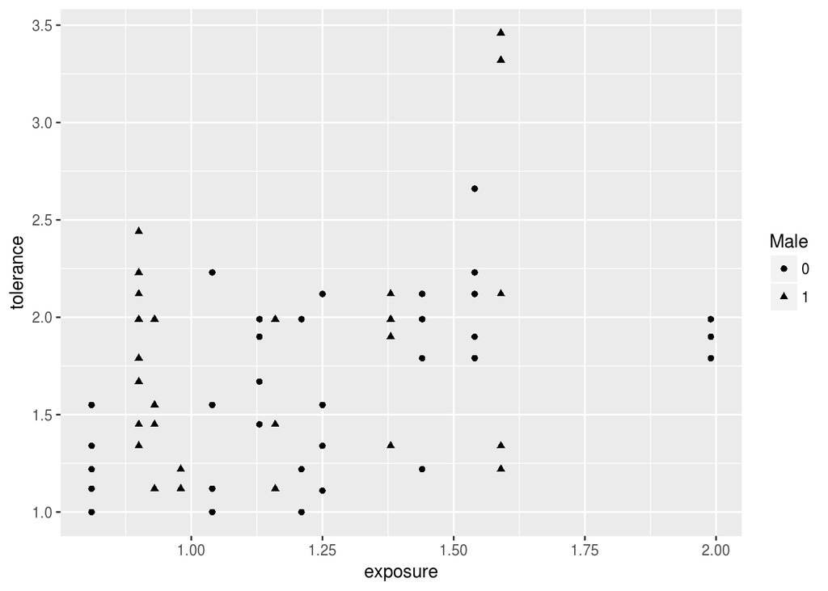

```r
library(ggplot2)
data$Male <- as.factor(data$male)
ggplot(data, aes(x=exposure, y=tolerance, shape=Male)) +
    geom_point()
```

## Part d

```r
maledata <- subset(data, male == 1)
femaledata <- subset(data, male == 0)
```

## Part e

```r
malemintime <- min(maledata$time)
malerangetol <- round(range(maledata$tolerance) ,2)
femalemintime <- min(femaledata$time)
femalerangetol <- round(range(femaledata$tolerance) ,2)
```

For males, the minimum value of time is 0. The range of tolerance is (1.12, 3.46).

For females, the minimum value of time is 0. The range of tolerance is (1, 2.66).

## Part f

```r
lm1 <- lm(tolerance ~ time + male + exposure, data=data)
```

## Part g

```r
library(pander)
pander(summary(lm1))
```

|  | Estimate | Std. Error | t value | Pr(>\|t\|) |
| --- | --- | --- | --- | --- |
| **(Intercept)** | 0.3703 | 0.1973 | 1.876 | 0.06443 |
| **time** | 0.1308 | 0.0314 | 4.166 | 8.124e-05 |
| **male** | 0.2295 | 0.09132 | 2.513 | 0.01407 |
| **exposure** | 0.7446 | 0.1423 | 5.232 | 1.439e-06 |

Fitting linear model: tolerance ~ time + male + exposure

| Observations | Residual Std. Error | $R^2$ | Adjusted $R^2$ |
| --- | --- | --- | --- |
| 80 | 0.3972 | 0.3821 | 0.3578 |